# Variable Selection Analysis - US Crime

HP

2024-02-05

*Using crime data from the file uscrime.txt (http://www.statsci.org/data/general/uscrime.txt, description at [http://www.statsci.org/data/general/uscrime.html),](http://www.statsci.org/data/general/uscrime.html),)

The purpose of this portion is to find the best model using variable selection techniques Stepwise Regression, LASSO, and Elastic Net

First, we read in and split the data.

```r
### Read in the data
crimedata <- read.table("data/uscrime.txt", stringsAsFactors = FALSE,
                        header = TRUE)

### Create training and testing sets for the data at 70% and 30%
sample <- sample(c(TRUE, FALSE), nrow(crimedata), replace=TRUE, prob=c(0.8,0.2))
ctrain <- crimedata[sample, ]
ctest <- crimedata[!sample, ]
```

## Stepwise Regression

### Build Step Regression on Trained Data

To complete the stepwise regression, I chose to use the train() function from the caret package. This function uses cross-validation to select the best number of variables. The parameters I set in the fucntion are: method = “leapseq” -> choses the stepwise regression function tuneGrid = data.frame(nvmax = 1:10) ->returns models with number of predictors from 1 to 10 trControl = train.control -> performs the cross validation based on the parameters set below

```r
## set up repeated k-fold cross-validation
train.control <- trainControl(method = "cv", number = 7)

## Train the model and perform step regression
ctrain_steps <- train(Crime ~., data = ctrain, method = "leapSeq",
                      tuneGrid = data.frame(nvmax = 1:10),
                      trControl = train.control)
ctrain_steps$results
```

```
##    nvmax     RMSE  Rsquared      MAE    RMSESD RsquaredSD     MAESD
## 1      1 296.2049 0.6152050 248.6768 118.10009  0.3502604 113.58193
## 2      2 360.0394 0.5436695 312.9594 114.96593  0.3217760  97.16901
## 3      3 311.5273 0.5037455 261.7866  48.76482  0.3288788  54.82047
## 4      4 345.6097 0.4358881 303.0923  83.81503  0.3088442  79.44642
## 5      5 315.9952 0.4980496 268.4111 112.65077  0.2873332  99.87013
## 6      6 366.9205 0.3856837 319.7069  72.72795  0.3084963  83.81460
## 7      7 352.7321 0.4016861 313.5937  93.00933  0.2506917  83.86234
## 8      8 381.0543 0.4098009 311.4581  79.90914  0.2638238  65.86756
## 9      9 351.3882 0.3554249 299.5120 101.18234  0.2480003  71.85565
## 10    10 394.9505 0.4077938 329.8733 122.96330  0.2161096 100.48587
```

The above output gives nvmax, the number of predictors used, RMSE and MAE. The lower these values the better the model. Rsquared is also defined in the model.

### Visual Analysis

To better visualize the data, I will make three plots, RMSE vs No of Predictors, Rsquared vs No of Predictors, and MAE vs No of predictors

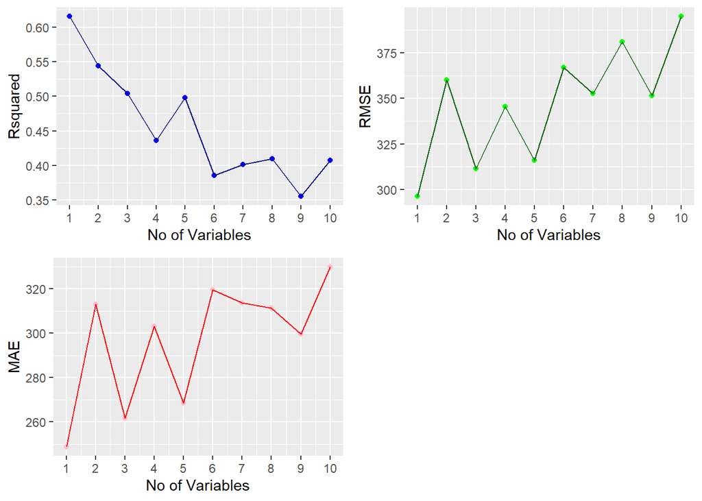

```r
## extract the table of results
res <- ctrain_steps$results

a <- ggplot(res, aes(x = nvmax, y= Rsquared)) + geom_point(color = "blue") +
  geom_line(color = "darkblue") + scale_x_continuous(name = "No of Variables",
                                                     breaks = seq(0,10,1))
b <- ggplot(res, aes(x = nvmax, y= RMSE)) + geom_point(color = "green") +
  geom_line(color = "darkgreen") + scale_x_continuous(name = "No of Variables",
                                                      breaks = seq(0,10,1))
c <- ggplot(res, aes(x = nvmax, y= MAE)) + geom_point(color = "pink") +
  geom_line(color = "red") + scale_x_continuous(name = "No of Variables",
                                                breaks = seq(0,10,1))

grid.arrange(a,b,c, nrow = 2)
```

Visually, the highest R-squared and lowest RMSE and MAE values are at the same node, P = 1. I will now check the output data to see if the model agrees. The optimal number of variables is found with $besttune

### Extra Best Value

```r
ctrain_steps$bestTune
```

```
##   nvmax
## 1     1
```

The model agrees with our visual inspection. One predictor seems very limited, however, so I will create a linear model only using the best coefficient and test it with our testing set.

```r
## Find the best coefficient
coef(ctrain_steps$finalModel, 1)
```

```
## (Intercept)         Po1
##    194.5689     79.6298
```

### Build Linear Regression Model

```r
## create linear model with one predictor
lm_1 <- lm(Crime ~ Po1, data = ctrain)
summary(lm_1)
```

```
##
## Call:
## lm(formula = Crime ~ Po1, data = ctrain)
##
## Residuals:
##     Min      1Q  Median      3Q     Max
## -473.42 -162.38    0.41  148.12  524.35
##
## Coefficients:
##             Estimate Std. Error t value Pr(>|t|)
## (Intercept)   194.57     142.94   1.361    0.184
## Po1            79.63      15.74   5.058 2.36e-05 ***
## ---
## Signif. codes:  0 '***' 0.001 '**' 0.01 '*' 0.05 '.' 0.1 ' ' 1
##
## Residual standard error: 282.1 on 28 degrees of freedom
## Multiple R-squared:  0.4775, Adjusted R-squared:  0.4588
## F-statistic: 25.59 on 1 and 28 DF,  p-value: 2.364e-05
```

Next I test the data by first finding the predicted values from our test model and the actual values.

### Test against Testing Set

```r
## calculate probability of default for each individual in test dataset
predicted <- predict.lm(lm_1, ctest)

## test against real responses
lm_mape <- MAPE(predicted, ctest$Crime)

paste0("Accuracy with 1 variable = ", round(lm_mape * 100, 2), "%")
```

```
## [1] "Accuracy with 1 variable = 25.35%"
```

This accuracy is VERY low. From the visual graphs before, the second best guess was with three variables. I will run this again using 3 variables instead of 1.

### Rerun experiment with 3 Variables

```r
## set up repeated k-fold cross-validation
train.control <- trainControl(method = "cv", number = 7)

## Train the model and perform step regression, set nvmax = 3
ctrain_steps <- train(Crime ~., data = ctrain, method = "leapSeq", tuneGrid = data.frame(nvmax = 3), trControl = train.control)
ctrain_steps$results
```

```
##   nvmax     RMSE  Rsquared      MAE   RMSESD RsquaredSD    MAESD
## 1     3 307.5426 0.5717612 253.7737 135.8655  0.3580069 102.2983
```

```r
## Find the best coefficients
coef(ctrain_steps$finalModel, 3)
```

```
## (Intercept)          Ed         Po1        Ineq
##  -3309.7474    173.7499    111.4960     72.8983
```

Now we have the variables to build the new regression model and test it agains the original data.

```r
## create linear model with three predictos
lm_3 <- lm(Crime ~ Ed + Po1 + Ineq, data = ctrain)

## calculate predicted values each individual in test dataset
predicted <- predict.lm(lm_3, ctest)

## test against real responses
lm_mape_3 <- MAPE(predicted, ctest$Crime)

paste0("Accuracy with 3 variables = ", round(lm_mape_3 * 100, 2), "%")
```

```
## [1] "Accuracy with 3 variables = 19.78%"
```

This accuracy is even lower, confirming using 1 variable provides the best model.

### Conclusion

Using Stepwise Regression, the best model comes from using one variable, Po1. It provies a model with R-squared = 0.6152050 and Accuracy = 25.35%.

## Lasso

### Run data in glmnet

Lasso is a Variable Selection technique that adds constraints to the regression equation. The sum of all coefficients cannot pass threshold T. In order to use glmet to perform this analysis, need to scale the predictors in the training data.

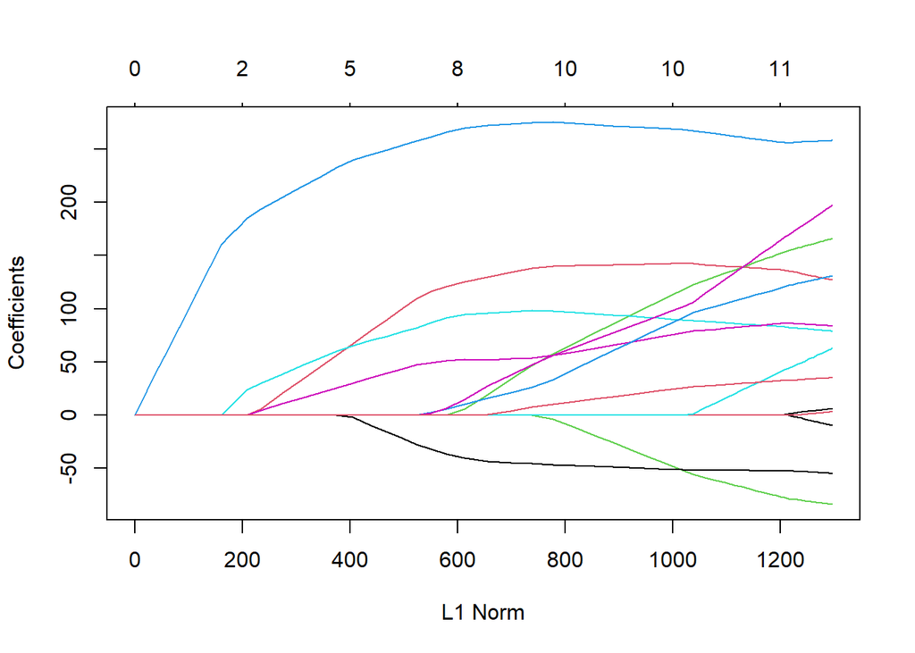

```r
## glmet requires R matrices to perform. I will create two matrices, one for the prediction variables and one for the response variables
## scale only the predictors
pred <- as.matrix(scale(ctrain[,-16]))
resp <- as.matrix(ctrain[,16])

## run the glmnet with alpha = 1, which will nullify the quadratic expression
lasso_c = glmnet(pred, resp, alpha = 1)
plot(lasso_c)
```

```r
print(lasso_c)
```

```
##
## Call:  glmnet(x = pred, y = resp, alpha = 1)
##
##    Df  %Dev  Lambda
## 1   0  0.00 260.600
## 2   1  8.11 237.400
## 3   1 14.84 216.300
## 4   1 20.43 197.100
## 5   1 25.06 179.600
## 6   1 28.92 163.600
## 7   1 32.11 149.100
## 8   1 34.77 135.900
## 9   1 36.97 123.800
## 10  1 38.80 112.800
## 11  1 40.32 102.800
```

[output cut: 63 more lines]

The data shows the number of variables against the deviance explanined at the value of $\lambda$, the penalty term for Lasso. To sample what one of the outputs is, I will extract the coefficients for $\lambda$ = 0.1

```r
coef(lasso_c, s = 0.1)
```

```
## 16 x 1 sparse Matrix of class "dgCMatrix"
##                     s1
## (Intercept) 869.033333
## M             5.759986
## So          126.950376
## Ed          165.708655
## Po1         258.107596
## Po2           .
## LF           78.765599
## M.F          83.710652
## Pop          -9.943815
## NW            2.999832
## U1          -84.029140
## U2          130.605616
## Wealth       62.627814
## Ineq        197.386354
## Prob        -55.067335
## Time         34.907965
```

### Extract optimal penalty terms

To chose the optimum $\lambda$, we can use the cross validation component in the glmnet pakcage.

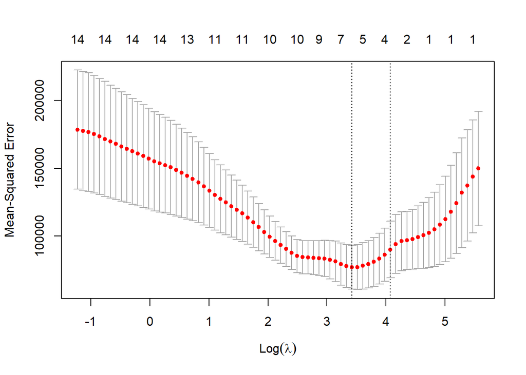

```r
## use cv.glmnet to extract optimum lambda
lasso_fit <- cv.glmnet(pred, resp)
plot(lasso_fit)
```

This is the plot of the cross-validation curve along the lambda sequence (error bars). The two vertical lines are lambda.min, the value that gives minimum mean cross-validation error, and lambda.1se, which gives the most regularized model.

I will extract the both lambda.min and lambda.lse and their coefficients.

```r
## coefficients for lambda.min
c("<------lambda.min------>")
```

```
## [1] "<------lambda.min------>"
```

```r
coef(lasso_fit, s = "lambda.min")
```

```
## 16 x 1 sparse Matrix of class "dgCMatrix"
##                    s1
## (Intercept) 869.03333
## M             .
## So          109.39048
## Ed            .
## Po1         257.65652
## Po2           .
## LF           81.87797
## M.F          46.93877
## Pop           .
## NW            .
## U1            .
## U2            .
## Wealth        .
## Ineq          .
## Prob        -27.38855
## Time          .
```

```r
## coefficients for lambda.1se
c("<------lambda.1se------>")
```

```
## [1] "<------lambda.1se------>"
```

```r
coef(lasso_fit, s = 'lambda.1se')
```

```
## 16 x 1 sparse Matrix of class "dgCMatrix"
##                    s1
## (Intercept) 869.03333
## M             .
## So           33.31619
## Ed            .
## Po1         214.83905
## Po2           .
## LF           46.29123
## M.F          16.14712
## Pop           .
## NW            .
## U1            .
## U2            .
## Wealth        .
## Ineq          .
## Prob          .
## Time          .
```

The lowest cross validation (lambda.min), usses many more coefficients than the most regularized model, lambda.lse. Using the built in cross validation, I next test the data using predictions from the models. I do one for lambda.min and one for lambda.1se.

### Test New Models

```r
## prediction for lambda.min
predict_min <- predict(lasso_fit, newx = pred, s = "lambda.min")

## test against real responses
mape_min <- MAPE(predict_min, ctrain$Crime)

paste0("Accuracy with lambda.min and 5 variables = ", round(mape_min * 100, 2),
       "%")
```

```
## [1] "Accuracy with lambda.min and 5 variables = 21.85%"
```

```r
## prediction for lambda.1se
predict_1se <- predict(lasso_fit, newx = pred, s = "lambda.1se")

## test against real responses
mape_1se <- MAPE(predict_1se, ctrain$Crime)

paste0("Accuracy with lambda.1se and 4 variables = ", round(mape_1se * 100, 2),
       "%")
```

```
## [1] "Accuracy with lambda.1se and 4 variables = 25.7%"
```

The model using the “most regularized” lambda value has higher accuracy, and is perhaps the more reliable model.

```r
## extract coefficients
coef(lasso_fit, s = "lambda.1se")
```

```
## 16 x 1 sparse Matrix of class "dgCMatrix"
##                    s1
## (Intercept) 869.03333
## M             .
## So           33.31619
## Ed            .
## Po1         214.83905
## Po2           .
## LF           46.29123
## M.F          16.14712
## Pop           .
## NW            .
## U1            .
## U2            .
## Wealth        .
## Ineq          .
## Prob          .
## Time          .
```

### Build Regression Model

The coefficients used in this model are So, Po1, LF, and M.F. I build a regression model on the training data with these predictors.

```r
lasso_lm <- lm(Crime ~ So + Po1 + LF + M.F, data = ctrain)
summary(lasso_lm)
```

```
##
## Call:
## lm(formula = Crime ~ So + Po1 + LF + M.F, data = ctrain)
##
## Residuals:
##     Min      1Q  Median      3Q     Max
## -433.82 -154.47   28.36  104.14  569.62
##
## Coefficients:
##             Estimate Std. Error t value Pr(>|t|)
## (Intercept) -4193.79    1459.41  -2.874  0.00816 **
## So            339.15      95.32   3.558  0.00153 **
## Po1            95.82      13.28   7.216 1.46e-07 ***
## LF           3013.46    1192.32   2.527  0.01819 *
## M.F            24.75      16.15   1.532  0.13798
## ---
## Signif. codes:  0 '***' 0.001 '**' 0.01 '*' 0.05 '.' 0.1 ' ' 1
##
## Residual standard error: 222.4 on 25 degrees of freedom
## Multiple R-squared:  0.7102, Adjusted R-squared:  0.6638
## F-statistic: 15.31 on 4 and 25 DF,  p-value: 1.868e-06
```

### Test against testing set

Next I test this data against the training testing set

```r
## prediction using the new model.
predict_lasso <- predict(lasso_lm, ctest)

## test against real responses
mape_lasso <- MAPE(predict_lasso, ctest$Crime)

paste0("Accuracy of lasso model to testing set = ", round(mape_lasso * 100, 2),
       "%")
```

```
## [1] "Accuracy of lasso model to testing set = 27.74%"
```

### Conclusion

This accuracy is better than used for the stepwise Regression, and it keeps So, Po1, LF, and M.F. as the variables.

## Elastic Net

Elastic is a Variable Selection technique that adds constraints to the regression equation: the absolute values of the sums of all coefficients and their squares. I use glmnet to perform this analysis, beginning midway through the analysis for Lasso.

### Build Models with Different $\alpha$ ’s

To perform Elastic Net regression, we will use the same beginning as used in the Lasso steps. We will deviate at the start of the cross validation, where I will test different levels of alpha.

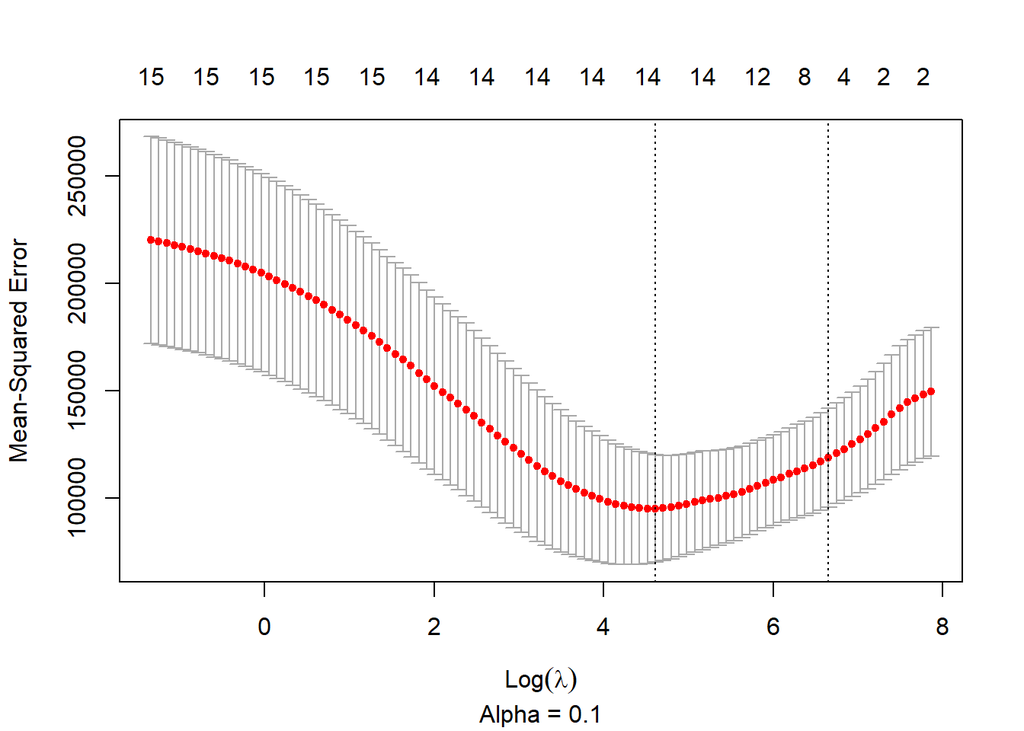

```r
## the foldid parameter to test for different alpha's
foldid <- sample(1:7, size = length(resp), replace = TRUE)

## create 5 models with different alpha's
cv_1 <- cv.glmnet(pred, resp, foldid = foldid, alpha = .1)
cv_3 <- cv.glmnet(pred, resp, foldid = foldid, alpha = .3)
cv_5 <- cv.glmnet(pred, resp, foldid = foldid, alpha = .5)
cv_7 <- cv.glmnet(pred, resp, foldid = foldid, alpha = .7)
cv_9 <- cv.glmnet(pred, resp, foldid = foldid, alpha = .9)

plot(cv_1, sub = "Alpha = 0.1")
```

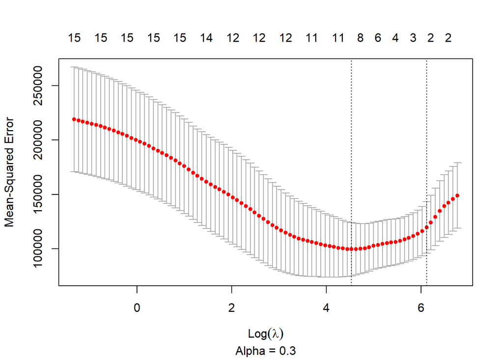

```r
plot(cv_3, sub = "Alpha = 0.3")
```

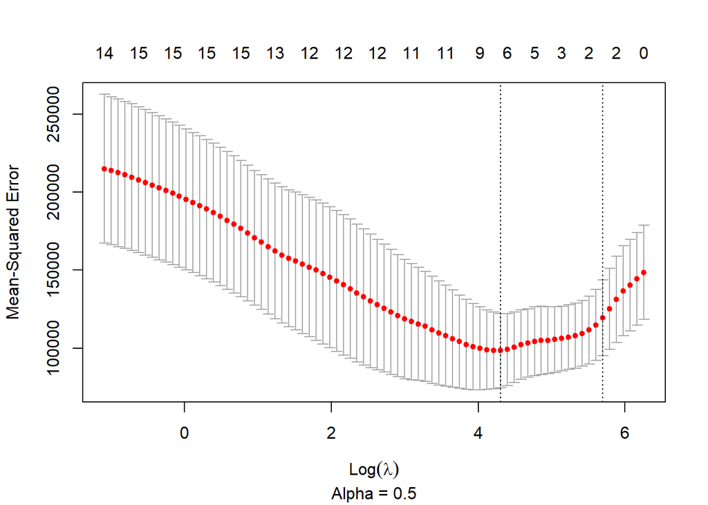

```r
plot(cv_5, sub = "Alpha = 0.5")
```

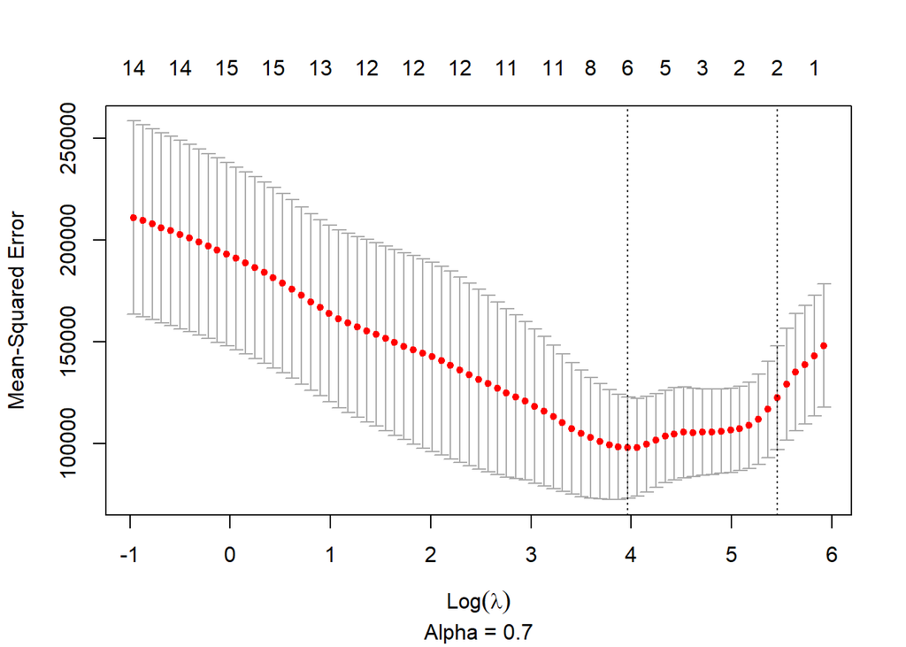

```r
plot(cv_7, sub = "Alpha = 0.7")
```

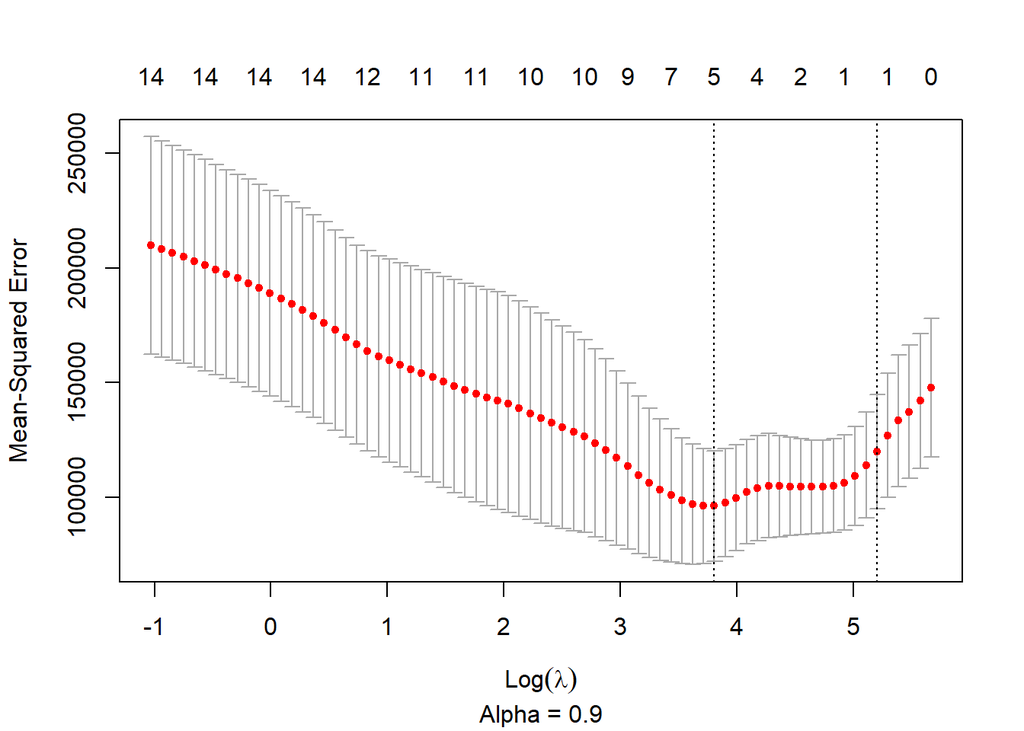

```r
plot(cv_9, sub = "Alpha = 0.9")
```

### Test for Accuracy

I created a function to extract the accuracy for the models.

```r
accuracy <- function(cv_model){
  predict_min <- predict(cv_model, newx = pred, s = "lambda.min")
  mape_min <- MAPE(predict_min, ctrain$Crime)
  paste0("Accuracy with lambda.min for ",deparse(substitute(cv_model)), " is ", round(mape_min * 100, 2), "%")
  ## prediction for lambda.1se
  predict_1se <- predict(cv_model, newx = pred, s = "lambda.1se")
  ## test against real responses
  mape_1se <- MAPE(predict_1se, ctrain$Crime)
  cat("Accuracy with lambda.1se for " , deparse(substitute(cv_model)), " is ", round(mape_1se * 100, 2), "%\n",
         "Accuracy with lambda.min for ",deparse(substitute(cv_model)), " is ", round(mape_min * 100, 2), "%\n")
}

accuracy(cv_1)
```

```
## Accuracy with lambda.1se for  cv_1  is  32.15 %
##  Accuracy with lambda.min for  cv_1  is  21.19 %
```

```r
accuracy(cv_3)
```

```
## Accuracy with lambda.1se for  cv_3  is  32.85 %
##  Accuracy with lambda.min for  cv_3  is  23.4 %
```

```r
accuracy(cv_5)
```

```
## Accuracy with lambda.1se for  cv_5  is  32.69 %
##  Accuracy with lambda.min for  cv_5  is  23.54 %
```

```r
accuracy(cv_7)
```

```
## Accuracy with lambda.1se for  cv_7  is  32.82 %
##  Accuracy with lambda.min for  cv_7  is  23.06 %
```

```r
accuracy(cv_9)
```

```
## Accuracy with lambda.1se for  cv_9  is  32.51 %
##  Accuracy with lambda.min for  cv_9  is  23.08 %
```

I will use this value and corresponding $\lambda$ to create the linear model against which I test the original data.

```r
## define best model
lasso_fit_e <- cv.glmnet(pred, resp, alpha = .9)
## extract coefficients
coef(lasso_fit_e, s = "lambda.1se")
```

```
## 16 x 1 sparse Matrix of class "dgCMatrix"
##                    s1
## (Intercept) 869.03333
## M             .
## So           42.63758
## Ed            .
## Po1         219.75291
## Po2           .
## LF           51.93911
## M.F          20.65551
## Pop           .
## NW            .
## U1            .
## U2            .
## Wealth        .
## Ineq          .
## Prob          .
## Time          .
```

### Build Regression Model

```r
lasso_lm_e <- lm(Crime ~ Po1, data = ctrain)
summary(lasso_lm_e)
```

```
##
## Call:
## lm(formula = Crime ~ Po1, data = ctrain)
##
## Residuals:
##     Min      1Q  Median      3Q     Max
## -473.42 -162.38    0.41  148.12  524.35
##
## Coefficients:
##             Estimate Std. Error t value Pr(>|t|)
## (Intercept)   194.57     142.94   1.361    0.184
## Po1            79.63      15.74   5.058 2.36e-05 ***
## ---
## Signif. codes:  0 '***' 0.001 '**' 0.01 '*' 0.05 '.' 0.1 ' ' 1
##
## Residual standard error: 282.1 on 28 degrees of freedom
## Multiple R-squared:  0.4775, Adjusted R-squared:  0.4588
## F-statistic: 25.59 on 1 and 28 DF,  p-value: 2.364e-05
```

### Test against testing set

Next I test this data against the training testing set

```r
## prediction using the new model.
predict_lasso_e <- predict(lasso_lm_e, ctest)

## test against real responses
mape_lasso_e <- MAPE(predict_lasso_e, ctest$Crime)

paste0("Accuracy of lasso model to testing set = ",
       round(mape_lasso_e * 100, 2), "%")
```

```
## [1] "Accuracy of lasso model to testing set = 25.35%"
```